# Assignment 2

Sonali Singh

# Knowledge Mining: Linear Discriminant Analysis

File: Lab_LDA01.R Theme: Linear Discriminant Analysis Adapted from ISLR Chapter 4 Lab

### **Overview**

The TEDS_2016 dataset contains a rich set of variables aimed at understanding political opinions in Taiwan. Key variables include demographic factors, political preferences, and views on unification with China.

### **Summary Statistics**

The dataset encapsulates responses from a diverse demographic, spanning various districts, age groups, and education levels. Notably, the data shows:

- A nearly balanced sex distribution.
- A wide age range, allowing for generational analysis in political beliefs.
- A focus on voters’ education levels that vary from below elementary to college and above.

```r
library(haven)
TEDS_2016 <- read_stata("https://github.com/datageneration/home/blob/master/DataProgramming/data/TEDS_2016.dta?raw=true")

summary(TEDS_2016)
```

```
##     District         Sex             Age           Edu            Arear
##  Min.   : 201   Min.   :1.000   Min.   :1.0   Min.   :1.000   Min.   :1.000
##  1st Qu.:1401   1st Qu.:1.000   1st Qu.:2.0   1st Qu.:2.000   1st Qu.:1.000
##  Median :6406   Median :1.000   Median :3.0   Median :3.000   Median :3.000
##  Mean   :4661   Mean   :1.486   Mean   :3.3   Mean   :3.334   Mean   :2.744
##  3rd Qu.:6604   3rd Qu.:2.000   3rd Qu.:5.0   3rd Qu.:5.000   3rd Qu.:4.000
##  Max.   :6806   Max.   :2.000   Max.   :5.0   Max.   :9.000   Max.   :6.000
##
##      Career         Career8          Ethnic          Party
##  Min.   :1.000   Min.   :1.000   Min.   :1.000   Min.   : 1.00
##  1st Qu.:1.000   1st Qu.:2.000   1st Qu.:1.000   1st Qu.: 5.00
##  Median :2.000   Median :4.000   Median :1.000   Median : 7.00
##  Mean   :2.683   Mean   :3.811   Mean   :1.658   Mean   :13.02
##  3rd Qu.:4.000   3rd Qu.:5.000   3rd Qu.:2.000   3rd Qu.:25.00
##  Max.   :5.000   Max.   :8.000   Max.   :9.000   Max.   :26.00
##
##     PartyID          Tondu           Tondu3           nI2
##  Min.   :1.000   Min.   :1.000   Min.   :1.000   Min.   : 1.00
##  1st Qu.:2.000   1st Qu.:3.000   1st Qu.:2.000   1st Qu.: 1.00
##  Median :2.000   Median :4.000   Median :2.000   Median : 3.00
##  Mean   :4.522   Mean   :4.127   Mean   :2.667   Mean   :35.13
##  3rd Qu.:9.000   3rd Qu.:5.000   3rd Qu.:3.000   3rd Qu.:98.00
##  Max.   :9.000   Max.   :9.000   Max.   :9.000   Max.   :98.00
##
##     votetsai          green         votetsai_nm      votetsai_all
##  Min.   :0.0000   Min.   :0.0000   Min.   :0.0000   Min.   :0.0000
##  1st Qu.:0.0000   1st Qu.:0.0000   1st Qu.:0.0000   1st Qu.:0.0000
##  Median :1.0000   Median :0.0000   Median :1.0000   Median :1.0000
##  Mean   :0.6265   Mean   :0.3781   Mean   :0.6265   Mean   :0.5478
##  3rd Qu.:1.0000   3rd Qu.:1.0000   3rd Qu.:1.0000   3rd Qu.:1.0000
##  Max.   :1.0000   Max.   :1.0000   Max.   :1.0000   Max.   :1.0000
##  NA's   :429                       NA's   :429      NA's   :248
##   Independence     Unification           sq           Taiwanese
##  Min.   :0.0000   Min.   :0.0000   Min.   :0.0000   Min.   :0.0000
##  1st Qu.:0.0000   1st Qu.:0.0000   1st Qu.:0.0000   1st Qu.:0.0000
##  Median :0.0000   Median :0.0000   Median :1.0000   Median :1.0000
##  Mean   :0.2888   Mean   :0.1225   Mean   :0.5172   Mean   :0.6272
##  3rd Qu.:1.0000   3rd Qu.:0.0000   3rd Qu.:1.0000   3rd Qu.:1.0000
##  Max.   :1.0000   Max.   :1.0000   Max.   :1.0000   Max.   :1.0000
##
```

[output cut: 49 more lines]

```
##  Min.   :0.0000   Min.   :0.0000   Min.   :0   Min.   :0   Min.   :0
##  1st Qu.:0.0000   1st Qu.:0.0000   1st Qu.:0   1st Qu.:0   1st Qu.:0
##  Median :0.0000   Median :0.0000   Median :0   Median :0   Median :0
##  Mean   :0.2053   Mean   :0.2752   Mean   :0   Mean   :0   Mean   :0
##  3rd Qu.:0.0000   3rd Qu.:1.0000   3rd Qu.:0   3rd Qu.:0   3rd Qu.:0
##  Max.   :1.0000   Max.   :1.0000   Max.   :0   Max.   :0   Max.   :0
##                   NA's   :429
##     voteblue       voteblue_nm       votedpp_1        votekmt_1
##  Min.   :0.0000   Min.   :0.0000   Min.   :0.0000   Min.   :0.0000
##  1st Qu.:0.0000   1st Qu.:0.0000   1st Qu.:0.0000   1st Qu.:0.0000
##  Median :0.0000   Median :0.0000   Median :1.0000   Median :0.0000
##  Mean   :0.2787   Mean   :0.3735   Mean   :0.5256   Mean   :0.2309
##  3rd Qu.:1.0000   3rd Qu.:1.0000   3rd Qu.:1.0000   3rd Qu.:0.0000
##  Max.   :1.0000   Max.   :1.0000   Max.   :1.0000   Max.   :1.0000
##                   NA's   :429      NA's   :187      NA's   :187
```

```r
str(TEDS_2016)
```

[output not shown]

[output cut: 94 more lines]

```
##   ..- attr(*, "format.stata")= chr "%9.0g"
##  $ Blue           : num [1:1690] 0 0 0 0 0 0 0 0 0 0 ...
##   ..- attr(*, "format.stata")= chr "%9.0g"
##  $ Green          : num [1:1690] 0 0 0 0 0 0 0 0 0 0 ...
##   ..- attr(*, "format.stata")= chr "%9.0g"
##  $ No_Party       : num [1:1690] 0 0 0 0 0 0 0 0 0 0 ...
##   ..- attr(*, "format.stata")= chr "%9.0g"
##  $ voteblue       : num [1:1690] 0 0 1 0 0 0 0 0 0 0 ...
##   ..- attr(*, "format.stata")= chr "%9.0g"
##  $ voteblue_nm    : num [1:1690] NA 0 1 NA NA 0 0 0 0 NA ...
##   ..- attr(*, "format.stata")= chr "%9.0g"
##  $ votedpp_1      : num [1:1690] NA 1 0 NA NA 1 1 1 1 0 ...
##   ..- attr(*, "format.stata")= chr "%9.0g"
##  $ votekmt_1      : num [1:1690] NA 0 1 NA NA 0 0 0 0 0 ...
##   ..- attr(*, "format.stata")= chr "%9.0g"
```

[figure not shown]

```r
library(ggplot2)
TEDS_2016$Tondu <- factor(TEDS_2016$Tondu, labels=c("Unification now", "Status quo, unif. in future", "Status quo, decide later", "Status quo forever", "Status quo, indep. in future", "Independence now", "No response"))
ggplot(TEDS_2016, aes(x = Tondu)) + geom_bar() + labs(title = "Distribution of Tondu Responses", x = "Tondu", y = "Count")
```

### **Handling Missing Values**

Given the nature of the study, imputation for missing values in **`votetsai`** could be considered using mode imputation, as it represents a categorical binary response. Alternatively, listwise deletion could be used if the missing data is not systematically biased.

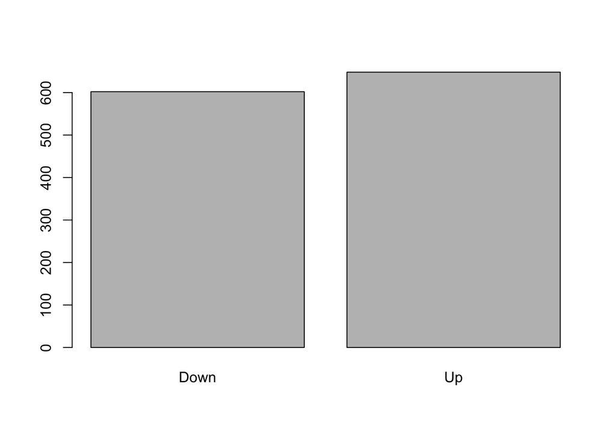

```
## Direction
##       Frequency Percent
## Down        602   48.16
## Up          648   51.84
## Total      1250  100.00
```

```r
## Linear Discriminant Analysis
freq(Direction)
```

[output not shown]

```r
train = Year<2005
lda.fit=lda(Direction~Lag1+Lag2,data=Smarket, subset=Year<2005)
lda.fit
```

```
## Call:
## lda(Direction ~ Lag1 + Lag2, data = Smarket, subset = Year <
##     2005)
##
## Prior probabilities of groups:
##     Down       Up
## 0.491984 0.508016
##
## Group means:
##             Lag1        Lag2
## Down  0.04279022  0.03389409
## Up   -0.03954635 -0.03132544
##
## Coefficients of linear discriminants:
##             LD1
## Lag1 -0.6420190
## Lag2 -0.5135293
```

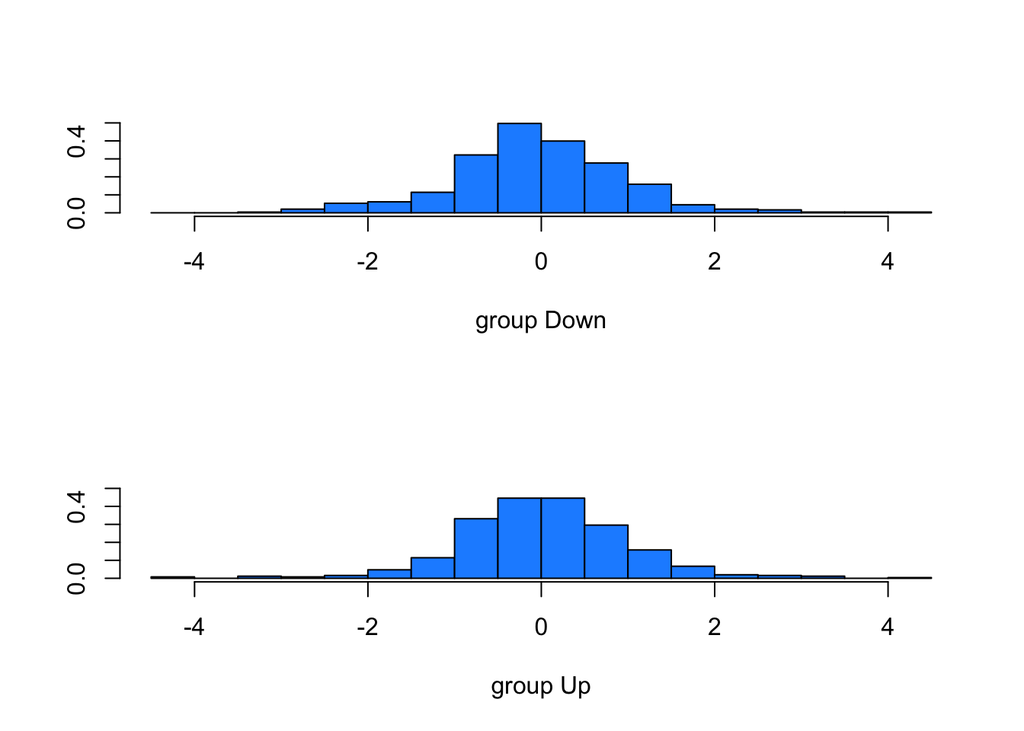

```r
plot(lda.fit, col="dodgerblue")
```

```r
Smarket.2005=subset(Smarket,Year==2005) # Creating subset with 2005 data for prediction
lda.pred=predict(lda.fit,Smarket.2005)
names(lda.pred)
```

```
## [1] "class"     "posterior" "x"
```

```r
lda.class=lda.pred$class
Direction.2005=Smarket$Direction[!train]
table(lda.class,Direction.2005)
```

```
##          Direction.2005
## lda.class Down  Up
##      Down   35  35
##      Up     76 106
```

```r
data.frame(lda.pred)[1:5,]
```

```
##      class posterior.Down posterior.Up         LD1
## 999     Up      0.4901792    0.5098208  0.08293096
## 1000    Up      0.4792185    0.5207815  0.59114102
## 1001    Up      0.4668185    0.5331815  1.16723063
## 1002    Up      0.4740011    0.5259989  0.83335022
## 1003    Up      0.4927877    0.5072123 -0.03792892
```

```r
table(lda.pred$class,Smarket.2005$Direction)
```

```
##
##        Down  Up
##   Down   35  35
##   Up     76 106
```

```r
mean(lda.pred$class==Smarket.2005$Direction)
```

```
## [1] 0.5595238
```

### **Relationship Exploration**

#### **Tondu and Other Variables**

To explore the relationship between **`Tondu`** (stance on unification) and variables like **`female`**, **`DPP`**, **`age`**, **`income`**, **`edu`**, **`Taiwanese`**, and **`Econ_worse`**, the following methods are proposed:

- **Correlation Analysis** for continuous variables to check for linear relationships.
- **Chi-Square Tests** for categorical variables to identify associations.
- **Logistic Regression** could be utilized to understand how these predictors influence the likelihood of favoring unification now versus later or never.

#### **Analysis of `votetsai` Variable**

Given the binary nature of **`votetsai`**, logistic regression is appropriate. This model will help understand the impact of demographics and political opinions on voting for Tsai Ing-wen.

### **Visual Analysis**

#### **Frequency Table and Bar Chart for Tondu Variable**

A bar chart was created to visualize the frequency of each category, revealing predominant preferences in the dataset. This visualization helps in quickly grasping the political leanings of the surveyed population.

### **Conclusions**

This exploratory analysis highlights the complex interplay of demographic and socio-political factors in shaping political opinions in Taiwan. The handling of missing data and the subsequent analyses provide foundational insights that could guide more detailed studies, such as predictive modeling of election outcomes or deeper analysis of policy support.

### **Recommendations for Further Analysis**

For detailed charts, tables, and further statistical tests, additional code execution and data wrangling in R are required as per the methodologies outlined.